# Case Study_Cyclistic bike-share analysis

KHIN MYO AYE

2022-05-21

# Summary

This project is Google Data Analytics Certificate capstone project. In project, all data use at Clyclistic, a bike-share company in Chicago. This company launched a successful bike-share offering in 2016, 5824 bicycles are geotracked and locked into a network of 692 stations across Chicago.

Cyclistic’s marketing strategy relied on building general awareness and appealing to broad consumer segments.Pricing plans are single-ride passes, full-day passes, and annual memberships.Customer can purchase single-ride or full-day passes are referred to as casual riders and annual memberships are Cyclistic members. Cyclistic’s finance analysts have concluded that annual members are much more profitable than casual riders.

The director of the marketing analyst team to find future success depends on maximizing the number of annual memberships.The team will design a new marketing strategy to convert casual riders into annual members.

The full document of case study can see [Google Data Analytics Capstone](https://www.coursera.org/learn/google-data-analytics-capstone)

## Step 1 : Ask

### Define the Business Problem

It is already known that annual members receive more revenue than casual riders. According to this situation, the key consideration is to persuade casual riders to become annual members.

### Business Task

The task is to identify the differences between casual riders and annual member, and to provide a relevant message to mobilize casual users to switch to annual subscriptions. So that, the first question to answer is : How do annual members and casual riders use Cyclistic bikes differently?

### Key Stakeholder Consideration

- Cyclistic Characters
- Marketing Director (Lily Moreno)
- Cyclistic Marketing Analytics Team
- Cyclistic Executive Team

## Step 2 : Prepare

### Data Preparation

##### **Data Source Location**

- All Cyclistic’s historical trip data collected from [Cyclistic’s trip dataset](https://divvy-tripdata.s3.amazonaws.com/index.html)
- The datasets have a different name because Cyclistic is a fictional company.
- The data has been made available by Motivate International Inc. under this [license](https://ride.divvybikes.com/data-license-agreement). So, this is public data.

##### **Data Organization**

I used sixteen csv files with thirteenth variables.

##### **Data Credibility**

The data look to appear in good sense and I did not find any duplicate records when I check it. In order to check ROCCC,

- **R**eliable : I guess these data are reliable that is why public dataset under license agreement
- **O**riginal : Yes
- **C**omprehensive : I guess most are comprehensive even though some missing data, we can use it
- **C**urrent : Yes, I use nearly sixteen months data
- **C**ited : Yes

##### **Sorting and Filtering**

I used twelve months of 2021 and four months of 2022 this was current data files. All data file have same variables and some are null or blank records. So I have to remove it using by filtering function in Excel. Before I process, some installing need to do.

##### **Setting Requirement Packages**

**Install required packages**

- tidyverse for data import and wrangling
- lubridate for date functions
- ggplot for visualization

```r
library(tidyverse) #helps wrangle data
library(lubridate)  #helps wrangle date attributes
```

```r
library(ggplot2)  #helps visualize data
library(dplyr)  # for efficiently manipulating datasets
library(tidyr)  #to help to create tidy or clean data
library(knitr)
getwd() #displays your working directory
```

```
## [1] "C:/Users/ASUS/Documents/Cyclistic_Blike_Share/Bike_Share"
```

**COLLECT All DATA**

loading all data from 01/2021 to 04/2022

```r
trip_2021_01 <-read.csv("C:/Users/ASUS/Documents/Cyclistic_Blike_Share/Bike_Share/202101-divvy-tripdata.csv")
trip_2021_02 <-read.csv("C:/Users/ASUS/Documents/Cyclistic_Blike_Share/Bike_Share/202102-divvy-tripdata.csv")
trip_2021_03 <-read.csv("C:/Users/ASUS/Documents/Cyclistic_Blike_Share/Bike_Share/202103-divvy-tripdata.csv")
trip_2021_04 <-read.csv("C:/Users/ASUS/Documents/Cyclistic_Blike_Share/Bike_Share/202104-divvy-tripdata.csv")
trip_2021_05 <-read.csv("C:/Users/ASUS/Documents/Cyclistic_Blike_Share/Bike_Share/202105-divvy-tripdata.csv")
trip_2021_06 <-read.csv("C:/Users/ASUS/Documents/Cyclistic_Blike_Share/Bike_Share/202106-divvy-tripdata.csv")
trip_2021_07 <-read.csv("C:/Users/ASUS/Documents/Cyclistic_Blike_Share/Bike_Share/202107-divvy-tripdata.csv")
trip_2021_08 <-read.csv("C:/Users/ASUS/Documents/Cyclistic_Blike_Share/Bike_Share/202108-divvy-tripdata.csv")
trip_2021_09 <-read.csv("C:/Users/ASUS/Documents/Cyclistic_Blike_Share/Bike_Share/202109-divvy-tripdata.csv")
trip_2021_10 <-read.csv("C:/Users/ASUS/Documents/Cyclistic_Blike_Share/Bike_Share/202110-divvy-tripdata.csv")
trip_2021_11 <-read.csv("C:/Users/ASUS/Documents/Cyclistic_Blike_Share/Bike_Share/202111-divvy-tripdata.csv")
trip_2021_12 <-read.csv("C:/Users/ASUS/Documents/Cyclistic_Blike_Share/Bike_Share/202112-divvy-tripdata.csv")
trip_2022_01 <-read.csv("C:/Users/ASUS/Documents/Cyclistic_Blike_Share/Bike_Share/202201-divvy-tripdata.csv")
trip_2022_02 <-read.csv("C:/Users/ASUS/Documents/Cyclistic_Blike_Share/Bike_Share/202202-divvy-tripdata.csv")
trip_2022_03 <-read.csv("C:/Users/ASUS/Documents/Cyclistic_Blike_Share/Bike_Share/202203-divvy-tripdata.csv")
trip_2022_04 <-read.csv("C:/Users/ASUS/Documents/Cyclistic_Blike_Share/Bike_Share/202204-divvy-tripdata.csv")
```

**WRANGLE DATA AND COMBINE IT INTO A SINGLE FILE**

Check the column names in each of the files is the same order or not, if not match by order, we must to update them before joining them into one file.

```r
colnames(trip_2021_01)
```

```
##  [1] "ride_id"            "rideable_type"      "started_at"
##  [4] "ended_at"           "start_station_name" "start_station_id"
##  [7] "end_station_name"   "end_station_id"     "start_lat"
## [10] "start_lng"          "end_lat"            "end_lng"
## [13] "member_casual"
```

```r
colnames(trip_2021_02)
```

```
##  [1] "ride_id"            "rideable_type"      "started_at"
##  [4] "ended_at"           "start_station_name" "start_station_id"
##  [7] "end_station_name"   "end_station_id"     "start_lat"
## [10] "start_lng"          "end_lat"            "end_lng"
## [13] "member_casual"
```

```r
colnames(trip_2021_03)
```

```
##  [1] "ride_id"            "rideable_type"      "started_at"
##  [4] "ended_at"           "start_station_name" "start_station_id"
##  [7] "end_station_name"   "end_station_id"     "start_lat"
## [10] "start_lng"          "end_lat"            "end_lng"
## [13] "member_casual"
```

```r
colnames(trip_2021_04)
```

```
##  [1] "ride_id"            "rideable_type"      "started_at"
##  [4] "ended_at"           "start_station_name" "start_station_id"
##  [7] "end_station_name"   "end_station_id"     "start_lat"
## [10] "start_lng"          "end_lat"            "end_lng"
## [13] "member_casual"
```

```r
colnames(trip_2021_05)
```

```
##  [1] "ride_id"            "rideable_type"      "started_at"
##  [4] "ended_at"           "start_station_name" "start_station_id"
##  [7] "end_station_name"   "end_station_id"     "start_lat"
## [10] "start_lng"          "end_lat"            "end_lng"
## [13] "member_casual"
```

```r
colnames(trip_2021_06)
```

```
##  [1] "ride_id"            "rideable_type"      "started_at"
##  [4] "ended_at"           "start_station_name" "start_station_id"
##  [7] "end_station_name"   "end_station_id"     "start_lat"
## [10] "start_lng"          "end_lat"            "end_lng"
## [13] "member_casual"
```

```r
colnames(trip_2021_07)
```

```
##  [1] "ride_id"            "rideable_type"      "started_at"
##  [4] "ended_at"           "start_station_name" "start_station_id"
##  [7] "end_station_name"   "end_station_id"     "start_lat"
## [10] "start_lng"          "end_lat"            "end_lng"
## [13] "member_casual"
```

```r
colnames(trip_2021_08)
```

```
##  [1] "ride_id"            "rideable_type"      "started_at"
##  [4] "ended_at"           "start_station_name" "start_station_id"
##  [7] "end_station_name"   "end_station_id"     "start_lat"
## [10] "start_lng"          "end_lat"            "end_lng"
## [13] "member_casual"
```

```r
colnames(trip_2021_09)
```

```
##  [1] "ride_id"            "rideable_type"      "started_at"
##  [4] "ended_at"           "start_station_name" "start_station_id"
##  [7] "end_station_name"   "end_station_id"     "start_lat"
## [10] "start_lng"          "end_lat"            "end_lng"
## [13] "member_casual"
```

```r
colnames(trip_2021_10)
```

```
##  [1] "ride_id"            "rideable_type"      "started_at"
##  [4] "ended_at"           "start_station_name" "start_station_id"
##  [7] "end_station_name"   "end_station_id"     "start_lat"
## [10] "start_lng"          "end_lat"            "end_lng"
## [13] "member_casual"
```

```r
colnames(trip_2021_11)
```

```
##  [1] "ride_id"            "rideable_type"      "started_at"
##  [4] "ended_at"           "start_station_name" "start_station_id"
##  [7] "end_station_name"   "end_station_id"     "start_lat"
## [10] "start_lng"          "end_lat"            "end_lng"
## [13] "member_casual"
```

```r
colnames(trip_2021_12)
```

```
##  [1] "ride_id"            "rideable_type"      "started_at"
##  [4] "ended_at"           "start_station_name" "start_station_id"
##  [7] "end_station_name"   "end_station_id"     "start_lat"
## [10] "start_lng"          "end_lat"            "end_lng"
## [13] "member_casual"
```

```r
colnames(trip_2022_01)
```

```
##  [1] "ride_id"            "rideable_type"      "started_at"
##  [4] "ended_at"           "start_station_name" "start_station_id"
##  [7] "end_station_name"   "end_station_id"     "start_lat"
## [10] "start_lng"          "end_lat"            "end_lng"
## [13] "member_casual"
```

```r
colnames(trip_2022_02)
```

```
##  [1] "ride_id"            "rideable_type"      "started_at"
##  [4] "ended_at"           "start_station_name" "start_station_id"
##  [7] "end_station_name"   "end_station_id"     "start_lat"
## [10] "start_lng"          "end_lat"            "end_lng"
## [13] "member_casual"
```

```r
colnames(trip_2022_03)
```

```
##  [1] "ride_id"            "rideable_type"      "started_at"
##  [4] "ended_at"           "start_station_name" "start_station_id"
##  [7] "end_station_name"   "end_station_id"     "start_lat"
## [10] "start_lng"          "end_lat"            "end_lng"
## [13] "member_casual"
```

```r
colnames(trip_2022_04)
```

```
##  [1] "ride_id"            "rideable_type"      "started_at"
##  [4] "ended_at"           "start_station_name" "start_station_id"
##  [7] "end_station_name"   "end_station_id"     "start_lat"
## [10] "start_lng"          "end_lat"            "end_lng"
## [13] "member_casual"
```

#### Combine all file of 2021 as a single file

```r
bike_share_2021<-bind_rows(trip_2021_01,trip_2021_02,trip_2021_03,trip_2021_04,
                           trip_2021_05,trip_2021_06,trip_2021_07,trip_2021_08,
                           trip_2021_09,trip_2021_10,trip_2021_11,trip_2021_12)
```

#### Combine all file of 2022 as a single file

```r
bike_share_2022<-bind_rows(trip_2022_01, trip_2022_02, trip_2022_03, trip_2022_04)
```

## Step 3 : Process

### Data Wrangling and Cleaning

**CLEAN UP AND ADD DATA TO PREPARE FOR ANALYSIS**

In this step, I would like to achieve clean data underlying complex dataset. To do so I considered the following processes:

#### Now let’s see what the data is look like

```r
View(bike_share_2021)
View(bike_share_2022)
```

#### Viewing the internal structure of all columns and data types such as numeric, character, etc

```r
str(bike_share_2021)
```

```
## 'data.frame':    5595063 obs. of  13 variables:
##  $ ride_id           : chr  "E19E6F1B8D4C42ED" "DC88F20C2C55F27F" "EC45C94683FE3F27" "4FA453A75AE377DB" ...
##  $ rideable_type     : chr  "electric_bike" "electric_bike" "electric_bike" "electric_bike" ...
##  $ started_at        : chr  "2021-01-23 16:14:19" "2021-01-27 18:43:08" "2021-01-21 22:35:54" "2021-01-07 13:31:13" ...
##  $ ended_at          : chr  "2021-01-23 16:24:44" "2021-01-27 18:47:12" "2021-01-21 22:37:14" "2021-01-07 13:42:55" ...
##  $ start_station_name: chr  "California Ave & Cortez St" "California Ave & Cortez St" "California Ave & Cortez St" "California Ave & Cortez St" ...
##  $ start_station_id  : chr  "17660" "17660" "17660" "17660" ...
##  $ end_station_name  : chr  "" "" "" "" ...
##  $ end_station_id    : chr  "" "" "" "" ...
##  $ start_lat         : num  41.9 41.9 41.9 41.9 41.9 ...
##  $ start_lng         : num  -87.7 -87.7 -87.7 -87.7 -87.7 ...
##  $ end_lat           : num  41.9 41.9 41.9 41.9 41.9 ...
##  $ end_lng           : num  -87.7 -87.7 -87.7 -87.7 -87.7 ...
##  $ member_casual     : chr  "member" "member" "member" "member" ...
```

```r
str(bike_share_2022)
```

```
## 'data.frame':    874670 obs. of  13 variables:
##  $ ride_id           : chr  "C2F7DD78E82EC875" "A6CF8980A652D272" "BD0F91DFF741C66D" "CBB80ED419105406" ...
##  $ rideable_type     : chr  "electric_bike" "electric_bike" "classic_bike" "classic_bike" ...
##  $ started_at        : chr  "2022-01-13 11:59:47" "2022-01-10 08:41:56" "2022-01-25 04:53:40" "2022-01-04 00:18:04" ...
##  $ ended_at          : chr  "2022-01-13 12:02:44" "2022-01-10 08:46:17" "2022-01-25 04:58:01" "2022-01-04 00:33:00" ...
##  $ start_station_name: chr  "Glenwood Ave & Touhy Ave" "Glenwood Ave & Touhy Ave" "Sheffield Ave & Fullerton Ave" "Clark St & Bryn Mawr Ave" ...
##  $ start_station_id  : chr  "525" "525" "TA1306000016" "KA1504000151" ...
##  $ end_station_name  : chr  "Clark St & Touhy Ave" "Clark St & Touhy Ave" "Greenview Ave & Fullerton Ave" "Paulina St & Montrose Ave" ...
##  $ end_station_id    : chr  "RP-007" "RP-007" "TA1307000001" "TA1309000021" ...
##  $ start_lat         : num  42 42 41.9 42 41.9 ...
##  $ start_lng         : num  -87.7 -87.7 -87.7 -87.7 -87.6 ...
##  $ end_lat           : num  42 42 41.9 42 41.9 ...
##  $ end_lng           : num  -87.7 -87.7 -87.7 -87.7 -87.6 ...
##  $ member_casual     : chr  "casual" "casual" "member" "casual" ...
```

#### How many rows are in data frame?

```r
nrow(bike_share_2021)
```

```
## [1] 5595063
```

```r
nrow(bike_share_2022)
```

```
## [1] 874670
```

#### Dimensions of the data frame

```r
dim(bike_share_2021)
```

```
## [1] 5595063      13
```

```r
dim(bike_share_2022)
```

```
## [1] 874670     13
```

####See the first 6 rows of data frame

```r
head(bike_share_2021)
```

```
##            ride_id rideable_type          started_at            ended_at
## 1 E19E6F1B8D4C42ED electric_bike 2021-01-23 16:14:19 2021-01-23 16:24:44
## 2 DC88F20C2C55F27F electric_bike 2021-01-27 18:43:08 2021-01-27 18:47:12
## 3 EC45C94683FE3F27 electric_bike 2021-01-21 22:35:54 2021-01-21 22:37:14
## 4 4FA453A75AE377DB electric_bike 2021-01-07 13:31:13 2021-01-07 13:42:55
## 5 BE5E8EB4E7263A0B electric_bike 2021-01-23 02:24:02 2021-01-23 02:24:45
## 6 5D8969F88C773979 electric_bike 2021-01-09 14:24:07 2021-01-09 15:17:54
##           start_station_name start_station_id end_station_name end_station_id
## 1 California Ave & Cortez St            17660
## 2 California Ave & Cortez St            17660
## 3 California Ave & Cortez St            17660
## 4 California Ave & Cortez St            17660
## 5 California Ave & Cortez St            17660
## 6 California Ave & Cortez St            17660
##   start_lat start_lng end_lat end_lng member_casual
## 1  41.90034 -87.69674   41.89  -87.72        member
## 2  41.90033 -87.69671   41.90  -87.69        member
## 3  41.90031 -87.69664   41.90  -87.70        member
## 4  41.90040 -87.69666   41.92  -87.69        member
## 5  41.90033 -87.69670   41.90  -87.70        casual
## 6  41.90041 -87.69676   41.94  -87.71        casual
```

```r
head(bike_share_2022)
```

```
##            ride_id rideable_type          started_at            ended_at
## 1 C2F7DD78E82EC875 electric_bike 2022-01-13 11:59:47 2022-01-13 12:02:44
## 2 A6CF8980A652D272 electric_bike 2022-01-10 08:41:56 2022-01-10 08:46:17
## 3 BD0F91DFF741C66D  classic_bike 2022-01-25 04:53:40 2022-01-25 04:58:01
## 4 CBB80ED419105406  classic_bike 2022-01-04 00:18:04 2022-01-04 00:33:00
## 5 DDC963BFDDA51EEA  classic_bike 2022-01-20 01:31:10 2022-01-20 01:37:12
## 6 A39C6F6CC0586C0B  classic_bike 2022-01-11 18:48:09 2022-01-11 18:51:31
##              start_station_name start_station_id              end_station_name
## 1      Glenwood Ave & Touhy Ave              525          Clark St & Touhy Ave
## 2      Glenwood Ave & Touhy Ave              525          Clark St & Touhy Ave
## 3 Sheffield Ave & Fullerton Ave     TA1306000016 Greenview Ave & Fullerton Ave
## 4      Clark St & Bryn Mawr Ave     KA1504000151     Paulina St & Montrose Ave
## 5   Michigan Ave & Jackson Blvd     TA1309000002        State St & Randolph St
## 6         Wood St & Chicago Ave              637       Honore St & Division St
##   end_station_id start_lat start_lng  end_lat   end_lng member_casual
## 1         RP-007  42.01280 -87.66591 42.01256 -87.67437        casual
## 2         RP-007  42.01276 -87.66597 42.01256 -87.67437        casual
## 3   TA1307000001  41.92560 -87.65371 41.92533 -87.66580        member
## 4   TA1309000021  41.98359 -87.66915 41.96151 -87.67139        casual
## 5   TA1305000029  41.87785 -87.62408 41.88462 -87.62783        member
## 6   TA1305000034  41.89563 -87.67207 41.90312 -87.67394        member
```

#### Statistical summarize all data by summary function

```r
summary(bike_share_2021)
```

```
##    ride_id          rideable_type       started_at          ended_at
##  Length:5595063     Length:5595063     Length:5595063     Length:5595063
##  Class :character   Class :character   Class :character   Class :character
##  Mode  :character   Mode  :character   Mode  :character   Mode  :character
##
##
##
##
##  start_station_name start_station_id   end_station_name   end_station_id
##  Length:5595063     Length:5595063     Length:5595063     Length:5595063
##  Class :character   Class :character   Class :character   Class :character
##  Mode  :character   Mode  :character   Mode  :character   Mode  :character
##
##
##
##
##    start_lat       start_lng         end_lat         end_lng
##  Min.   :41.64   Min.   :-87.84   Min.   :41.39   Min.   :-88.97
##  1st Qu.:41.88   1st Qu.:-87.66   1st Qu.:41.88   1st Qu.:-87.66
##  Median :41.90   Median :-87.64   Median :41.90   Median :-87.64
##  Mean   :41.90   Mean   :-87.65   Mean   :41.90   Mean   :-87.65
##  3rd Qu.:41.93   3rd Qu.:-87.63   3rd Qu.:41.93   3rd Qu.:-87.63
##  Max.   :42.07   Max.   :-87.52   Max.   :42.17   Max.   :-87.49
##                                   NA's   :4771    NA's   :4771
##  member_casual
##  Length:5595063
##  Class :character
##  Mode  :character
##
##
##
##
```

```r
summary(bike_share_2022)
```

```
##    ride_id          rideable_type       started_at          ended_at
##  Length:874670      Length:874670      Length:874670      Length:874670
##  Class :character   Class :character   Class :character   Class :character
##  Mode  :character   Mode  :character   Mode  :character   Mode  :character
##
##
##
##
##  start_station_name start_station_id   end_station_name   end_station_id
##  Length:874670      Length:874670      Length:874670      Length:874670
##  Class :character   Class :character   Class :character   Class :character
##  Mode  :character   Mode  :character   Mode  :character   Mode  :character
##
##
##
##
##    start_lat       start_lng         end_lat         end_lng
##  Min.   :41.65   Min.   :-87.84   Min.   :41.63   Min.   :-87.85
##  1st Qu.:41.88   1st Qu.:-87.66   1st Qu.:41.88   1st Qu.:-87.66
##  Median :41.90   Median :-87.64   Median :41.90   Median :-87.64
##  Mean   :41.90   Mean   :-87.65   Mean   :41.90   Mean   :-87.65
##  3rd Qu.:41.93   3rd Qu.:-87.63   3rd Qu.:41.93   3rd Qu.:-87.63
##  Max.   :45.64   Max.   :-73.80   Max.   :42.08   Max.   :-87.51
##                                   NA's   :746     NA's   :746
##  member_casual
##  Length:874670
##  Class :character
##  Mode  :character
##
##
##
##
```

**Drop all Null(Cleaning Null)**

There are 4771 NA’s in bike_share_2021 and also have 746 NA’s in bike_share_2022 after checking with summarize function. So, I drop NA using drop_na function and check again clean data frame.

```r
clean_bike_share_2021<-drop_na(bike_share_2021)
View(clean_bike_share_2021)
dim(clean_bike_share_2021)
```

```
## [1] 5590292      13
```

```r
clean_bike_share_2022<-drop_na(bike_share_2022)
View(clean_bike_share_2022)
dim(clean_bike_share_2022)
```

```
## [1] 873924     13
```

#### **Data Acquisition (Add Column)**

Add columns that list the date, month, day, and year of each ride This will allow us to aggregate ride data for each month, day, or year … before completing these operations we could only aggregate at the ride level

```r
clean_bike_share_2021$date <- as.Date(clean_bike_share_2021$started_at) #The default format is yyyy-mm-dd
clean_bike_share_2021$month <- format(as.Date(clean_bike_share_2021$date), "%m")
clean_bike_share_2021$day <- format(as.Date(clean_bike_share_2021$date), "%d")
clean_bike_share_2021$year <- format(as.Date(clean_bike_share_2021$date), "%Y")
clean_bike_share_2021$day_of_week <- format(as.Date(clean_bike_share_2021$date), "%A")
```

```r
clean_bike_share_2022$date <- as.Date(clean_bike_share_2022$started_at)
clean_bike_share_2022$month <- format(as.Date(clean_bike_share_2022$date), "%m")
clean_bike_share_2022$day <- format(as.Date(clean_bike_share_2022$date), "%d")
clean_bike_share_2022$year <- format(as.Date(clean_bike_share_2022$date), "%Y")
clean_bike_share_2022$day_of_week <- format(as.Date(clean_bike_share_2022$date), "%A")
```

#### Add a “ride_length” calculation to all clean_bike_share data frame(in seconds)

```r
clean_bike_share_2021$ride_length <- difftime(clean_bike_share_2021$ended_at,clean_bike_share_2021$started_at)
```

```r
clean_bike_share_2022$ride_length <- difftime(clean_bike_share_2022$ended_at,clean_bike_share_2022$started_at)
```

#### Inspect the structure of the columns

```r
str(clean_bike_share_2021)
```

```
## 'data.frame':    5590292 obs. of  19 variables:
##  $ ride_id           : chr  "E19E6F1B8D4C42ED" "DC88F20C2C55F27F" "EC45C94683FE3F27" "4FA453A75AE377DB" ...
##  $ rideable_type     : chr  "electric_bike" "electric_bike" "electric_bike" "electric_bike" ...
##  $ started_at        : chr  "2021-01-23 16:14:19" "2021-01-27 18:43:08" "2021-01-21 22:35:54" "2021-01-07 13:31:13" ...
##  $ ended_at          : chr  "2021-01-23 16:24:44" "2021-01-27 18:47:12" "2021-01-21 22:37:14" "2021-01-07 13:42:55" ...
##  $ start_station_name: chr  "California Ave & Cortez St" "California Ave & Cortez St" "California Ave & Cortez St" "California Ave & Cortez St" ...
##  $ start_station_id  : chr  "17660" "17660" "17660" "17660" ...
##  $ end_station_name  : chr  "" "" "" "" ...
##  $ end_station_id    : chr  "" "" "" "" ...
##  $ start_lat         : num  41.9 41.9 41.9 41.9 41.9 ...
##  $ start_lng         : num  -87.7 -87.7 -87.7 -87.7 -87.7 ...
##  $ end_lat           : num  41.9 41.9 41.9 41.9 41.9 ...
##  $ end_lng           : num  -87.7 -87.7 -87.7 -87.7 -87.7 ...
##  $ member_casual     : chr  "member" "member" "member" "member" ...
##  $ date              : Date, format: "2021-01-23" "2021-01-27" ...
##  $ month             : chr  "01" "01" "01" "01" ...
##  $ day               : chr  "23" "27" "21" "07" ...
##  $ year              : chr  "2021" "2021" "2021" "2021" ...
##  $ day_of_week       : chr  "Saturday" "Wednesday" "Thursday" "Thursday" ...
##  $ ride_length       : 'difftime' num  625 244 80 702 ...
##   ..- attr(*, "units")= chr "secs"
```

```r
str(clean_bike_share_2022)
```

```
## 'data.frame':    873924 obs. of  19 variables:
##  $ ride_id           : chr  "C2F7DD78E82EC875" "A6CF8980A652D272" "BD0F91DFF741C66D" "CBB80ED419105406" ...
##  $ rideable_type     : chr  "electric_bike" "electric_bike" "classic_bike" "classic_bike" ...
##  $ started_at        : chr  "2022-01-13 11:59:47" "2022-01-10 08:41:56" "2022-01-25 04:53:40" "2022-01-04 00:18:04" ...
##  $ ended_at          : chr  "2022-01-13 12:02:44" "2022-01-10 08:46:17" "2022-01-25 04:58:01" "2022-01-04 00:33:00" ...
##  $ start_station_name: chr  "Glenwood Ave & Touhy Ave" "Glenwood Ave & Touhy Ave" "Sheffield Ave & Fullerton Ave" "Clark St & Bryn Mawr Ave" ...
##  $ start_station_id  : chr  "525" "525" "TA1306000016" "KA1504000151" ...
##  $ end_station_name  : chr  "Clark St & Touhy Ave" "Clark St & Touhy Ave" "Greenview Ave & Fullerton Ave" "Paulina St & Montrose Ave" ...
##  $ end_station_id    : chr  "RP-007" "RP-007" "TA1307000001" "TA1309000021" ...
##  $ start_lat         : num  42 42 41.9 42 41.9 ...
##  $ start_lng         : num  -87.7 -87.7 -87.7 -87.7 -87.6 ...
##  $ end_lat           : num  42 42 41.9 42 41.9 ...
##  $ end_lng           : num  -87.7 -87.7 -87.7 -87.7 -87.6 ...
##  $ member_casual     : chr  "casual" "casual" "member" "casual" ...
##  $ date              : Date, format: "2022-01-13" "2022-01-10" ...
##  $ month             : chr  "01" "01" "01" "01" ...
##  $ day               : chr  "13" "10" "25" "04" ...
##  $ year              : chr  "2022" "2022" "2022" "2022" ...
##  $ day_of_week       : chr  "Thursday" "Monday" "Tuesday" "Tuesday" ...
##  $ ride_length       : 'difftime' num  177 261 261 896 ...
##   ..- attr(*, "units")= chr "secs"
```

#### Convert “ride_length” from factor to numeric so we can run calculations on the data

```r
is.factor(clean_bike_share_2021$ride_length)
```

```
## [1] FALSE
```

```r
clean_bike_share_2021$ride_length <- as.numeric(as.character(clean_bike_share_2021$ride_length))
is.numeric(clean_bike_share_2021$ride_length)
```

```
## [1] TRUE
```

```r
is.factor(clean_bike_share_2022$ride_length)
```

```
## [1] FALSE
```

```r
clean_bike_share_2022$ride_length <- as.numeric(as.character(clean_bike_share_2022$ride_length))
is.numeric(clean_bike_share_2022$ride_length)
```

```
## [1] TRUE
```

#### Remove “missing” data

The data frame includes a few hundred entries when bikes were taken out of docks and checked for quality by Divvy or ride_length was negative We will create a new update data frame since data is being removed

```r
update_clean_bike_share_2021 <- clean_bike_share_2021[!(clean_bike_share_2021$start_station_name == "HQ QR" | clean_bike_share_2021$ride_length<0),]
```

```r
update_clean_bike_share_2022 <- clean_bike_share_2022[!(clean_bike_share_2022$start_station_name == "HQ QR" | clean_bike_share_2022$ride_length<0),]
```

## Step 4: Analyze

### Identifying Trends and Relationships

**CONDUCT DESCRIPTIVE ANALYSIS**

Now, I performed some calculations such as mean, median, max and min values of ride_length for casual and member type users to identify the differences behavior between casual and member users

#### Descriptive analysis on ride_length of 2021(all figures in seconds)

1. straight average (total ride length / rides)
2. midpoint number in the ascending array of ride lengths
3. longest ride
4. shortest ride

```r
mean(update_clean_bike_share_2021$ride_length)
```

```
## [1] 1258.928
```

```r
median(update_clean_bike_share_2021$ride_length)
```

```
## [1] 719
```

```r
max(update_clean_bike_share_2021$ride_length)
```

```
## [1] 3356649
```

```r
min(update_clean_bike_share_2021$ride_length)
```

```
## [1] 0
```

#### Descriptive analysis on ride_length of 2022(all figures in seconds)

```r
mean(update_clean_bike_share_2022$ride_length)
```

```
## [1] 910.089
```

```r
median(update_clean_bike_share_2022$ride_length)
```

```
## [1] 541
```

```r
max(update_clean_bike_share_2022$ride_length)
```

```
## [1] 2061244
```

```r
min(update_clean_bike_share_2022$ride_length)
```

```
## [1] 0
```

#### I can condense the four lines above to one line using summary() on the specific attribute

```r
summary(update_clean_bike_share_2021$ride_length)
```

```
##    Min. 1st Qu.  Median    Mean 3rd Qu.    Max.
##       0     404     719    1259    1304 3356649
```

```r
summary(update_clean_bike_share_2022$ride_length)
```

```
##      Min.   1st Qu.    Median      Mean   3rd Qu.      Max.
##       0.0     310.0     541.0     910.1     987.0 2061244.0
```

#### Compare members and casual users

```r
aggregate(update_clean_bike_share_2021$ride_length ~ update_clean_bike_share_2021$member_casual, FUN = mean)
```

```
##   update_clean_bike_share_2021$member_casual
## 1                                     casual
## 2                                     member
##   update_clean_bike_share_2021$ride_length
## 1                                1814.2818
## 2                                 801.2881
```

```r
aggregate(update_clean_bike_share_2021$ride_length ~ update_clean_bike_share_2021$member_casual, FUN = median)
```

```
##   update_clean_bike_share_2021$member_casual
## 1                                     casual
## 2                                     member
##   update_clean_bike_share_2021$ride_length
## 1                                      957
## 2                                      576
```

```r
aggregate(update_clean_bike_share_2021$ride_length ~ update_clean_bike_share_2021$member_casual, FUN = max)
```

```
##   update_clean_bike_share_2021$member_casual
## 1                                     casual
## 2                                     member
##   update_clean_bike_share_2021$ride_length
## 1                                  3356649
## 2                                    89996
```

```r
aggregate(update_clean_bike_share_2021$ride_length ~ update_clean_bike_share_2021$member_casual, FUN = min)
```

```
##   update_clean_bike_share_2021$member_casual
## 1                                     casual
## 2                                     member
##   update_clean_bike_share_2021$ride_length
## 1                                        0
## 2                                        0
```

```r
aggregate(update_clean_bike_share_2022$ride_length ~ update_clean_bike_share_2022$member_casual, FUN = mean)
```

```
##   update_clean_bike_share_2022$member_casual
## 1                                     casual
## 2                                     member
##   update_clean_bike_share_2022$ride_length
## 1                                1446.7379
## 2                                 688.2667
```

```r
aggregate(update_clean_bike_share_2022$ride_length ~ update_clean_bike_share_2022$member_casual, FUN = median)
```

```
##   update_clean_bike_share_2022$member_casual
## 1                                     casual
## 2                                     member
##   update_clean_bike_share_2022$ride_length
## 1                                      799
## 2                                      469
```

```r
aggregate(update_clean_bike_share_2022$ride_length ~ update_clean_bike_share_2022$member_casual, FUN = max)
```

```
##   update_clean_bike_share_2022$member_casual
## 1                                     casual
## 2                                     member
##   update_clean_bike_share_2022$ride_length
## 1                                  2061244
## 2                                    89995
```

```r
aggregate(update_clean_bike_share_2022$ride_length ~ update_clean_bike_share_2022$member_casual, FUN = min)
```

```
##   update_clean_bike_share_2022$member_casual
## 1                                     casual
## 2                                     member
##   update_clean_bike_share_2022$ride_length
## 1                                        0
## 2                                        0
```

#### See the average ride time by each day for members vs casual users

```r
aggregate(update_clean_bike_share_2021$ride_length ~ update_clean_bike_share_2021$member_casual + update_clean_bike_share_2021$day_of_week, FUN = mean)
```

```
##    update_clean_bike_share_2021$member_casual
## 1                                      casual
## 2                                      member
## 3                                      casual
## 4                                      member
## 5                                      casual
## 6                                      member
## 7                                      casual
## 8                                      member
## 9                                      casual
## 10                                     member
## 11                                     casual
## 12                                     member
## 13                                     casual
## 14                                     member
```

[output cut: 30 more lines]

```r
aggregate(update_clean_bike_share_2022$ride_length ~ update_clean_bike_share_2022$member_casual + update_clean_bike_share_2022$day_of_week, FUN = mean)
```

```
##    update_clean_bike_share_2022$member_casual
## 1                                      casual
## 2                                      member
## 3                                      casual
## 4                                      member
## 5                                      casual
## 6                                      member
## 7                                      casual
## 8                                      member
## 9                                      casual
## 10                                     member
## 11                                     casual
## 12                                     member
## 13                                     casual
## 14                                     member
```

[output cut: 30 more lines]

#### Notice that the days of the week are out of order. Let’s fix that.

```r
update_clean_bike_share_2021$day_of_week <- ordered(update_clean_bike_share_2021$day_of_week, levels=c("Sunday", "Monday", "Tuesday", "Wednesday", "Thursday", "Friday", "Saturday"))
```

```r
update_clean_bike_share_2022$day_of_week <- ordered(update_clean_bike_share_2022$day_of_week, levels=c("Sunday", "Monday", "Tuesday", "Wednesday", "Thursday", "Friday", "Saturday"))
```

#### Now, let’s run the average ride time by each day for members vs casual users

```r
aggregate(update_clean_bike_share_2021$ride_length ~ update_clean_bike_share_2021$member_casual + update_clean_bike_share_2021$day_of_week, FUN = mean)
```

```
##    update_clean_bike_share_2021$member_casual
## 1                                      casual
## 2                                      member
## 3                                      casual
## 4                                      member
## 5                                      casual
## 6                                      member
## 7                                      casual
## 8                                      member
## 9                                      casual
## 10                                     member
## 11                                     casual
## 12                                     member
## 13                                     casual
## 14                                     member
```

[output cut: 30 more lines]

```r
aggregate(update_clean_bike_share_2022$ride_length ~ update_clean_bike_share_2022$member_casual + update_clean_bike_share_2022$day_of_week, FUN = mean)
```

```
##    update_clean_bike_share_2022$member_casual
## 1                                      casual
## 2                                      member
## 3                                      casual
## 4                                      member
## 5                                      casual
## 6                                      member
## 7                                      casual
## 8                                      member
## 9                                      casual
## 10                                     member
## 11                                     casual
## 12                                     member
## 13                                     casual
## 14                                     member
```

[output cut: 30 more lines]

#### analyze ridership data by type and weekday

1. creates weekday field using wday()
2. groups by user type and weekday
3. calculates the number of rides and average duration
4. calculates the average duration
5. sorts

```r
  update_clean_bike_share_2021 %>%
  mutate(weekday = wday(started_at, label = TRUE)) %>%
  group_by(member_casual, weekday) %>%
  summarise(number_of_rides = n()
            ,average_duration = mean(ride_length)) %>%
  arrange(member_casual, weekday)
```

```
## # A tibble: 14 x 4
## # Groups:   member_casual [2]
##    member_casual weekday number_of_rides average_duration
##    <chr>         <ord>             <int>            <dbl>
##  1 casual        Sun              480356            2120.
##  2 casual        Mon              285992            1817.
##  3 casual        Tue              274059            1603.
##  4 casual        Wed              278616            1574.
##  5 casual        Thu              285672            1563.
##  6 casual        Fri              363580            1717.
##  7 casual        Sat              557181            1966.
##  8 member        Sun              375925             915.
##  9 member        Mon              416018             776.
## 10 member        Tue              465347             754.
## 11 member        Wed              477000             758.
## 12 member        Thu              451346             752.
## 13 member        Fri              446219             783.
## 14 member        Sat              432835             895.
```

```r
  update_clean_bike_share_2022 %>%
  mutate(weekday = wday(started_at, label = TRUE)) %>%
  group_by(member_casual, weekday) %>%
  summarise(number_of_rides = n()
          ,average_duration = mean(ride_length)) %>%
  arrange(member_casual, weekday)
```

```
## # A tibble: 14 x 4
## # Groups:   member_casual [2]
##    member_casual weekday number_of_rides average_duration
##    <chr>         <ord>             <int>            <dbl>
##  1 casual        Sun               42573            1634.
##  2 casual        Mon               33254            1452.
##  3 casual        Tue               29823            1185.
##  4 casual        Wed               29949            1310.
##  5 casual        Thu               33148            1322.
##  6 casual        Fri               29075            1166.
##  7 casual        Sat               57765            1725.
##  8 member        Sun               68194             758.
##  9 member        Mon               95113             680.
## 10 member        Tue              104837             654.
## 11 member        Wed               95722             663.
## 12 member        Thu               96369             660.
## 13 member        Fri               79755             663.
## 14 member        Sat               78345             774.
```

#### Let’s visualize the number of rides by rider type

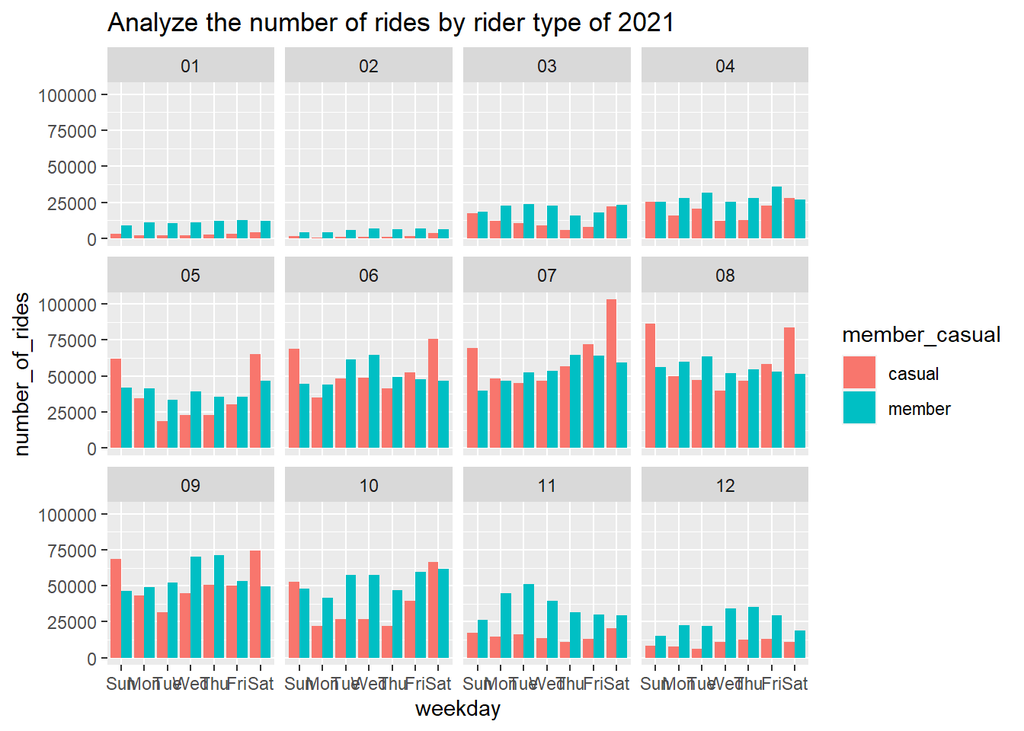

```r
  update_clean_bike_share_2021 %>%
  mutate(weekday = wday(started_at, label = TRUE)) %>%
  group_by(member_casual, weekday, month) %>%
  summarise(number_of_rides = n()
            ,average_duration = mean(ride_length)) %>%
  arrange(member_casual, weekday)  %>%
  ggplot(aes(x = weekday, y = number_of_rides, fill = member_casual)) +
  geom_col(position = "dodge")+
  facet_wrap(~month) +
  labs(title="Analyze the number of rides by rider type of 2021")
```

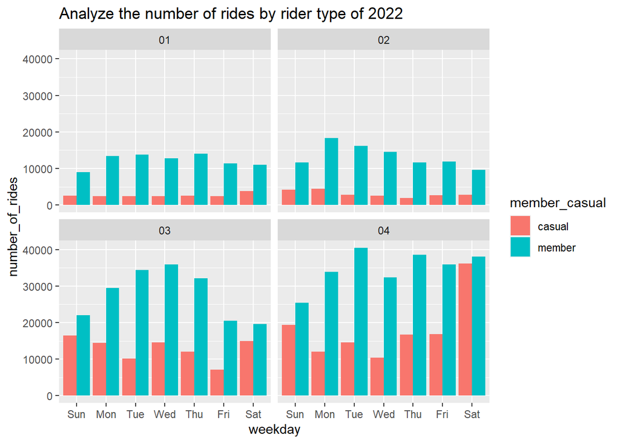

```r
  update_clean_bike_share_2022 %>%
  mutate(weekday = wday(started_at, label = TRUE)) %>%
  group_by(member_casual, weekday, month) %>%
  summarise(number_of_rides = n()
            ,average_duration = mean(ride_length)) %>%
  arrange(member_casual, weekday)  %>%
  ggplot(aes(x = weekday, y = number_of_rides, fill = member_casual)) +
  geom_col(position = "dodge")+
  facet_wrap(~month) +
  labs(title="Analyze the number of rides by rider type of 2022")
```